Running head: MODELING MINDLESS CHOICE 1

Modeling mindless choice

Seo Wook Choi, Peter Craigmile, Mario Peruggia and Trisha Van Zandt

The Ohio State University

MODELING MINDLESS CHOICE 2

Modeling mindless choice

Abstract

Experiment participants sometimes do not pay attention to the task that

experimenters provide. To manage this problem, researchers often implement data

preprocessing techniques to discriminate "good data" from "bad data". The most

commonly used data preprocessing technique is a removal of data points. Such

preprocessing is problematic for two reasons. First, deciding what is "bad data" is based

on a researcher’s subjective criterion. Second, "bad data" might be generated by an

underlying process which is theoretically interesting, and knowing about that process

might help to understand the data better. Discarding data without deep consideration,

then, wastes time, money and potentially useful information. In this project, we are

suggesting an alternative to discarding data. Instead of making rid of unexpected data,

the "bad data" generating process should be modeled explicitly. The key concept behind

this modeling is a Markov process which can describe choice dependency between trials.

Using Bayesian hierarchical modeling, we are suggesting that stimulus-unrelated

response processes can be separated from the stimulus-based response process, instead

of discarding outlier data points.

MODELING MINDLESS CHOICE 3

Introduction

Determining causality between two variables requires a controlled experimental

design in which one variable is independent, the other is dependent, and potentially

confounding variables are controlled. Psychological experiments do not easily reveal the

causal structures that researchers are interested in studying because it is diﬃcult to

control for all possible confounding variables when dealing with human beings with

diﬀerent backgrounds, experiences, motivations, and so forth. In particular, there is no

guarantee that participants in an experiment will follow the directions provided to them

by the researcher or focus on the task properly. This means that human experimental

data is very messy. Measurements reﬂect the inﬂuence of these unknown confounding

variables and the willingness or unwillingness of the participant to put forth his or her

best eﬀorts.

Because psychological data often seem to contain measurements that are

inconsistent, extreme or uninterpretable, there has been a great deal of eﬀort by

psychological researchers on the best ways to deal with "bad data" (Zimmerman, 1994).

The techniques proposed usually involve some kind of "data preprocessing." Data

preprocessing is the transformation or removal of measurements to produce a data set

that can be used to extract better information about the process of interest.

For example, human performance data consist of response times and response

accuracies collected during the performance of a choice reaction task. During a choice

reaction task, participants are shown a stimulus and required to select one of a small

number of possible responses to that stimulus. For example, during a signal detection

task, a participant may be shown a random ﬁeld containing some number of dots and

be asked to determine if that number of dots is "high" or "low." Perhaps the most

common method of data preprocessing is the removal of outliers. An outlier might be a

response time that is too fast or too slow, relative to the other response times provided

by that participant. Or, at the level of the participant, his or her accuracy may be very

low relative to the other participants in the study.

If a response time is very fast or very slow, say, more than 4 standard deviations

MODELING MINDLESS CHOICE 4

from the participant’s mean response time, or if the participant performs no better than

chance, the researcher may decide to eliminate those very fast or very slow response

times, or eliminate all the measurements provided by that participant. While throwing

away data in this way may result in data that seem more interpretable (or even

meaningful), it is problematic for at least three reasons.

First, discarding data necessarily wastes time and money. It is not always easy to

ﬁnd participants, bring them into the laboratory, and train them to do the necessary

tasks. Research assistants and often the participants themselves must be paid for their

time.

Second, in addition to the loss of time and money, throwing away data risks a loss

of information. Participants who seem to be performing badly may do so because of the

experimental conditions and not because they are failing to perform the task as

required. Discarding "bad data" may eliminate data that might otherwise provide

valuable information about the process being studied. A major goal of the research in

this paper is to extract information even from "bad data," or at least isolate "bad data"

from "good data," and so arrive at better methods of analysis, which in turn result in

better clariﬁcation of the phenomena of interest.

Third, determining which data are to be discarded relies on ad hoc criteria chosen

after the researcher has examined the data. Ad hoc procedures leave open the possibility

that researcher bias may inﬂuence the results. Removing outliers, for example, reduces

the variability of the measurements that have been retained, which in turn could

decrease the p-value of the test statistic computed for inferential tests using those data.

Instead of the removal of outliers from data, this paper will suggest a new

framework for the analysis of psychological data without data preprocessing. This

framework is based on the notion that it is possible to model the process that generates

"bad data" simultaneously with the cognitive process of interest. Such a modeling

strategy allows us to isolate data from the process of interest and so arrive at a clearer

understanding of that process.

To understand how we plan to accomplish this goal, imagine a participant in an

MODELING MINDLESS CHOICE 5

experiment who ignores the instructions from the experimenter and does something

unrelated to the task and the stimuli presented. In such a situation, that participant’s

responses should be unrelated to the stimuli presented, and we might expect that the

participant’s responses would look like a random sequence. However, the key to this

framework is the fact that human participants cannot generate truly random response

sequences. Previous studies show that, when participants try to generate completely

random binary sequences, they produce sequences that usually show negative

dependencies across responses (Bakan, 1960; Wagenaar, 1972) indicating that

participants tend to alternate their responses at rates greater than chance.

Consider now a participant whose performance is no better than chance. There

are two reasons why this might have occurred. The ﬁrst reason is that the participant

was not performing the task as instructed, and in this situation, we might expect to see

sequential dependencies (either positive or negative) across responses. The second

reason is that the participant was performing the task as instructed, but had diﬃculty

and so performed badly. In this situation, we might expect to see fewer sequential

dependencies across responses and more responses that depend on the presented

stimuli. Our goal is to model the participant’s response sequence as a mixture of

responses, some from a model of the task (perhaps with parameters set to very low

performance), and some from a process that describes the probabilities of repeating and

alternating responses in a way that is independent from the stimulus. To do this, we

will use a simple stochastic process, a Markov chain, that can produce response

dependencies across trials (Taylor & Karlin, 1998).

A Markov chain process speciﬁes that the probability of a particular response on a

trial only depends on the response made on the previous trial but not on any earlier

trials. If the stimuli are chosen randomly from trial to trial, and so the stimulus

sequence has no sequential dependencies, any observed dependencies across responses

must arise from a process unrelated to the stimuli. A Markov chain process might be a

good way to describe this task–unrelated response process.

In contrast to the stimulus-independent process, there must also exist a cognitive

MODELING MINDLESS CHOICE 6

process that permits responses executed as a result of processing the stimuli. For a

two-choice task, signal detection theory (SDT) is a well-known model that is commonly

used to describe response accuracy and response bias in simple decision-making (Green

& Swets, 1966). An SDT process can describe the generation of responses during the

performance of the task, and its parameters will determine the accuracy of the

participant’s responses, but these responses will depend only on the stimuli and will not

show any sequential dependencies.

Under the model that this paper will suggest, these two processes, the Markov

chain and the SDT process, are treated as two components of a dichotomous response

process. On any trial, there is some probability that the executed response comes from

either the Markov chain or the SDT process. This probability will be higher or lower for

diﬀerent participants, permitting us to detect which participants focus on the task and

which do not. In short, using SDT and a Markov chain process, the response sequence

is a sample from a mixture of these two diﬀerent processes, one that is based on the

stimulus and the other that is based on previous responses. This mixture model will

form the basis of a Bayesian hierarchical model that can be ﬁt to data from a

magnitude judgment task. The hierarchical structure permits diﬀerent participants to

have diﬀerent response strategies, as well as diﬀerent performance levels for the task.

Background

Human performance data usually consists of two primary dependent measures:

response accuracy and response time (RT). In the previous chapter, We outlined the

problem this project addresses: cleaning these kinds of data to remove the eﬀects of

outliers. More generally, we seek a way to isolate data arising from the cognitive process

of interest from those arising from other processes. In this chapter, We will ﬁrst

introduce the most common ways of handling outliers. It is important to note that most

of these methods concern RTs but not accuracy. This approach, in contrast to these

methods, is to develop a model that can separate cognitive-based from

non-cognitive-based responses. The model, a hierarchical Bayesian structure, includes

MODELING MINDLESS CHOICE 7

components consisting of Markov chains, signal detection theory (SDT), and probability

mixtures.

There are three ways to deal with an observation that is suspected to be an outlier

or a contaminant: 1) ignore it, and include it with the other observations for analysis;

2) remove it on the basis of some criterion usually based on the distance of the

observation from some measure of central tendency; or 3) transform it so that its

distance from the center of the observations is reduced.

Outlier removal is probably the most popular method of data preprocessing

(Barnett & Lewis, 1994; Hawkins, 1980). The primary concern with outlier removal is

to specify an objective criterion to which observations can be compared. This criterion

is usually determined by the distance from the sample mean or median in standard

deviations. This "restricted mean" method is the most well-known way to identify

outliers. The method speciﬁes the number of standard deviations (e.g., 2.0, 2.5, 3.0) a

data point can fall from the mean before being considered as an outlier. All

observations that fall outside this restricted range are excluded, and the restricted mean

is computed from all observations within the restricted range. Although the restricted

mean is a very useful and easy way to preprocess data, the standard deviation criterion

is nonetheless arbitrary. It is impossible to determine that extreme data points are not

generated by the process of interest. Furthermore, if arbitrary criteria are selected in a

post hoc manner, then the criteria can be abused to produce results favorable to a

researcher’s hypothesis.

For human performance data, a special problem arises from the positively skewed

nature of RT distributions. It is diﬃcult to apply the outlier treatments, devised for

data from skewed distributions, to normally- or symmetrically-distributed data.

However, Ulrich and Miller (1994) warn that cutoﬀs based on standard deviations may

cause biased estimates of the mean, because truncation may exclude extreme

measurements from the tail of the distribution. In the case of RT distributions, which

are skewed to the right, truncation results in greater bias for mean estimates. Instead of

using the mean and standard deviation to establish a criterion, the median and

MODELING MINDLESS CHOICE 8

interquartile range might be used. However, according to Ratcliﬀ (1993), using the

median and interquartile range lowers the statistical power of hypothesis testing.

Another way to manage outliers is a modiﬁed version of the cutoﬀ method called

winsorizing (Hastings, Mosteller, Tukey, & Winsor, 1947). Winsorized observations are

those exceed a quantile cutoﬀ and are replaced with the values of that cutoﬀ (either

upper or lower). However, windsorizing is problematic when the underlying distribution

is asymmetric (Rivest, 1994).

Instead of removing or transforming outlier values, the entire data set can be

transformed. These include transformation techniques such as inversion, logarithm,

root-based, trigonometric-based and so forth. For data X, the inverse transformation

replaces all observations with 1/X and the log transformation replaces all observations

with log(X). The goal of such transformations is to produce distributions that are as

symmetric or normal as possible. For positively-skewed measurements, the inverse

transformation 1/X compresses the right tail into the left tail, usually between 0 and 1.

Because the transformation is discontinuous at 0, it is not usually applied to

measurements taking on both negative and positive values. The log transformation

log(X) can only be applied to positive X values. This transformation compresses the

right tail of the distribution and expands the left tail. Because response times are

always positive, both transformations have been applied to reduce the inﬂuence of

extreme values and to produce transformed RT distributions that are more symmetric.

Ratcliﬀ (1993) recommended using inversion. He showed that this transformation

reduces the eﬀect of outliers on the mean without a loss of statistical power. Also,

because 1/RT is speed, the transformed values are easy to interpret. However,

transformation techniques also have inherent problems. The transformation may

diminish interpretability. The inversion of time to speed is a rare case that only

applicable to chronometric data. Also, because there is no standard transformation for

various kinds of human performance data, it is diﬃcult to say that a transformation

that worked in past research will work for future research. Furthermore, if a

transformation technique is chosen after examining the eﬀects of several diﬀerent

MODELING MINDLESS CHOICE 9

transformations, the false positive rate may increase. Because of these problems, no

single method for dealing with outliers is completely satisfactory. In this paper, we are

suggesting a modeling method that uses all the data without data preprocessing.

Recent research by Craigmile, Peruggia, Van Zandt and colleagues has provided

some alternatives to data preprocessing (Craigmile, Peruggia, & Van Zandt, 2010; Kim,

Potter, Craigmile, Peruggia, & Van Zandt, 2016). Craigmile et al.’s research focused on

human performance data consisting of accuracy and response times (RTs). RT data, in

general, contains fast and slow responses that are far from the bulk of the observations

and so they might be considered outliers; that is, observations that arise from processes

diﬀerent from the one under study. However, RT distributions are positively skewed

(Van Zandt, 2002), so it is diﬃcult to determine which slow RTs are outliers. Similarly,

it can be diﬃcult to determine which fast RTs are outliers. Rather than trying to

identify contaminant observations with the goal of discarding them, Craigmile et al.

have proposed to model them explicitly. Craigmile et al. (2010) presented a descriptive

framework within which log RTs were modeled as an autoregressive process of order 1

(AR(1)). Each RT was assumed to arise from this process, but there was some

probability that the RT was incremented or decremented by an amount that was

exponentially distributed. Fluctuations in the log RTs over time were described using a

wavelet regression model. With this structure, outliers and sequential eﬀects across

trials could be captured and separated from the (normal) log RT distribution.

Embedding this structure within a Bayesian hierarchical model allowed them to explain

both RTs from the cognitive process of interest and the outliers generated by a diﬀerent

process with a single framework.

The major problem with this approach was that the model on the log RTs was not

theoretically motivated. In part to address this problem, Kim et al. (2016) analyzed RT

and accuracy data from a (two-choice) recognition memory task as the output of a

Poisson race model (Audley & Pike, 1965; Townsend & Ashby, 1965; Van Zandt,

Colonius, & Proctor, 2000). The Poisson race model, an information accumulation

model, has parameters for a rate of information accumulation and response thresholds.

MODELING MINDLESS CHOICE 10

Like Craigmile et al. (2010), Kim et al. assumed that fast and slow contaminant

responses were mixed with the responses arising from the Poisson race process.

Sequential eﬀects were modeled as an AR(1) process on the log thresholds. Kim et al.

showed that this model was able to identify contaminants and, in addition, by breaking

the choice process into stimulus- and response-based components, characterize

participants’ poor performance in diﬀerent, theoretically important ways. In particular,

some participants performed poorly because they had trouble with the task (which

showed up as process-relevant parameters that indicated poor memory encoding or

retrieval), whereas others performed poorly because they did not focus on the task at

all (which showed up as contaminant process parameters that overwhelmed the memory

process).

The fact that a complete model needs to identify when people are or are not

performing a task leads us to this project. In this project, we will focus only on the

responses that people make in two- or three-choice tasks and not the RTs. To model

these choice tasks, we will use a signal detection theory (SDT) framework. This

framework will be embedded in a Bayesian hierarchical mixture model in which

responses arise both from the SDT process and from a Markov chain process that

describes decision making when a person is not paying attention. This approach

exploits the idea that dependencies across responses should only arise when the

participant is not paying attention (the Markov chain process), but there should be no

dependencies when s/he is paying attention (the SDT process). we will explain this

logic in more detail below.

General ideas of modeling

Where do outliers come from? Why would we want to remove them? The idea is

that we have one process of interest that we are trying to study (the process by which

stimuli are interpreted and appropriate responses to those stimuli are selected), and

other processes that generate contaminant observations and make it diﬃcult to draw

conclusions from the data about the process of interest. We often ask experiment

MODELING MINDLESS CHOICE 11

participants to perform tasks for close to an hour (or more), and we can’t expect that

these participants have perfectly sustained their concentration on the task for this

length of time.

In this project, we will exploit the idea that contaminant responses should come

from processes that are independent of the stimuli presented in the trials for which

those responses were executed. The data collected over the trials in an experiment are

therefore a mixture of stimulus-based and stimulus-independent responses. we will focus

only on the responses and not the response times for this project.

In a two-choice task, if the stimuli are presented randomly (i.e., an independent

and identically distributed sequence of stimuli) and participants’ responses only depend

on the stimulus, the responses should also be an independent and identically distributed

sequence. If the responses are being generated by a process that does not depend on the

presented stimulus, then they may or may not be independent and identically

distributed. However, we have empirical evidence to suggest that responses from trials

where participants are not paying attention are not independent and identically

distributed. This evidence comes from two sources. First, in almost all experiments

there are response dependencies between trials. For example, responses that are

repeated are generally faster than responses that are not (Logan, 1990; Remington,

1969). Second, and the most important, people are unable to generate random

sequences when they are asked to do so (Bakan, 1960; Wagenaar, 1972).

If responses to stimuli are independent from each other, and responses arising

from stimulus-independent processes are not, then we can look for dependencies across

trials to determine when people are paying attention and when they are not. From this

idea, we are going to model two-choice response as a mixture of two diﬀerent processes,

one that depends on the stimulus and one that does not. Each component of the

mixture will be based on two diﬀerent models of the response process. we will describe

each component and then integrate them into a mixture model that can be ﬁt to data

with a Bayesian hierarchical framework.

Because the stimuli are independent across trials, any dependency on the

MODELING MINDLESS CHOICE 12

responses implies that there is some other process causing the dependence that is

diﬀerent from the process of interest.

This paper will focus on detecting dependency between trials under the

assumption that such dependency cannot be attributable to the process of interest.

Such dependencies can be modeled by a simple Markov chain process without requiring

elaborate theories about the structure that produces the responses. Consider a sequence

of responses {R

1

, R

2

, . . .} where R

i

is a binary variable that takes on values 0 or 1. A

Markov chain is a random process such that the probability that R

i

= r depends only

on R

i−1

but on no other preceding states {R

1

, R

2

, . . . , R

i−2

} (Taylor & Karlin, 1998).

The behavior of a two-state Markov chain is determined by a transition probability

matrix such as

P

i

=

0 1

0 p

i

1 − p

i

1 1 − p

i

p

i

, (1)

where the subscript i indicates the individual. The number "0" represents a "noise" and

"1" represents a "signal" response. The columns represent the current response state,

and the rows represent the previous response state. If the previous state was 0, the

probability that the next state is also 0 is p

i

, and the probability that the next state is 1

is 1 − p

i

. If the previous state is 1, the probability that the next state is 1 is p

i

, and the

probability that the next state is 0 is 1 − p

i

. Therefore p

i

is the probability that

previous response is repeated. Modeling response selection with the Markov chain

deﬁned by Equation 1 assumes that the stimulus has no inﬂuence on the response, or

that the participant is not paying attention to the stimulus. The symmetry of the

matrix P

i

represents a very simple model that explains only response repetitions and

alternations. The symmetry of P

i

reduces the number of model parameters so that the

model can be ﬁt to the data more easily.

To model response selection when participants are paying attention, we will

implement Signal Detection Theory (SDT; Green and Swets (1966)). SDT provides an

explanation of how people distinguish signals from noise. For example, suppose a doctor

MODELING MINDLESS CHOICE 13

has to make a diagnosis of disease (leukemia) from a blood sample containing some

number of white blood cells. She does not know whether the patient is sick or not. We

call a blood sample from a sick patient a signal and a blood sample from a healthy

patient noise. There is always variability in the sample. The number of white blood

cells varies across people, so it is possible that a sample of healthy blood has a high

number of white blood cells or sample from a sick person’s blood may have a low

number of white blood cells. So, signals and noise are not always discriminable.

The SDT model has two parameters to describe the response selection process.

The diﬀerence between the means of the signal and noise distributions is d

0

, or

discriminability. High values of d

0

mean that a doctor can discriminate healthy blood

from sick blood very well. If d

0

is close to zero it means that a doctor cannot diagnose

disease from blood at all, so the decision is no diﬀerent from a random guess. The

second parameter c, the criterion, describes the intensity of the stimulus required to

choose a "signal" response. High values of c mean that more evidence is needed to make

a "signal" decision. A doctor with a high criterion will only make a diagnosis of sickness

when the number of white blood cells is very high. Such high criteria are referred to as

"conservative." Low criteria are referred to as "liberal."

We will write the presented stimulus as S

ik

= 0 (noise) or 1 (signal) for individual

i on trial k. Assuming that the distributions of noise and signals are Gaussian, and that

the individual has criterion c

i

and perceived discriminability d

i

. we assume that the

mean of the noise distribution is 0 and that the variance of both distributions is 1.

Then, given the stimulus S

ik

, the probability of making a noise response is Φ (c

i

− S

ik

d

i

)

and the probability of making a signal response is then 1 − Φ (c − S

ik

d

i

) where Φ is the

normal cumulative distribution function (CDF). We can put these probabilities into a

transition matrix like that of Equation 1, yielding

φ

ik

=

Φ (c

i

− S

ik

d

i

) 1 − Φ (c

i

− S

ik

d

i

)

Φ (c

i

− S

ik

d

i

) 1 − Φ (c

i

− S

ik

d

i

)

. (2)

Comparing the two transition probability matrices in Equation 1 and 2, we see

that the probability of a noise response in Equation 1 depends on the previous response

MODELING MINDLESS CHOICE 14

whereas in Equation 2 it does not; the columns of the transition matrix φ

ik

are identical.

Assuming that both processes contribute to the responses collected from an

individual, for each trial there is a binary selection between the stimulus-based and

stimulus-independent processes. The stimulus-based process is selected with probability

ρ

i

and the stimulus-independent process is selected with probability 1 − ρ

i

. This

Bernoulli process integrates the two diﬀerent models. The parameter ρ

i

can be

interpreted as the probability of properly responding to the stimulus as the

experimenter intended, and 1 − ρ

i

as the probability of doing something else. High ρ

i

means that it is more likely that a decision is generated by the stimulus-based response

process, and low ρ

i

means that it is more likely that a decision is generated by the

stimulus-independent response process.

In this study, a distinguishing point of the research is the mixture of the

probabilities of two diﬀerent response strategies. Bayesian hierarchical modeling can

oﬀer a framework for ﬁtting this model to data. Bayesian hierarchical modeling is used

to estimate the posterior distributions of multilevel parameters. In Bayesian statistics,

because the parameters are also considered random variables, it is possible to estimate

their posterior distributions using Bayes’ theorem,

P (θ | X) =

P (X | θ) P (θ)

P (X)

, (3)

for data X and parameters θ. The probability P(θ) is the prior distribution of θ, P(X|θ)

is the model likelihood, and P(θ|X) is the posterior distribution of θ, for individual i,

θ

i

= {p

i

, d

i

, c

i

, ρ

i

}. All inferences about the parameters, both at the individual and the

group-level, arise from the posterior distributions. Hierarchical models are used to

analyze data that arise from variability at diﬀerent levels of a process. For example, in

this study, participants make decisions on each trial. Each decision is determined by

individual traits. Those traits are determined by the group to which each individual

belongs. Trial-level variability is governed by individual-level parameters, and

individual-level variability is governed by group-level parameters (hyperparameters).

The posteriors of the parameters of complex hierarchical models rarely have

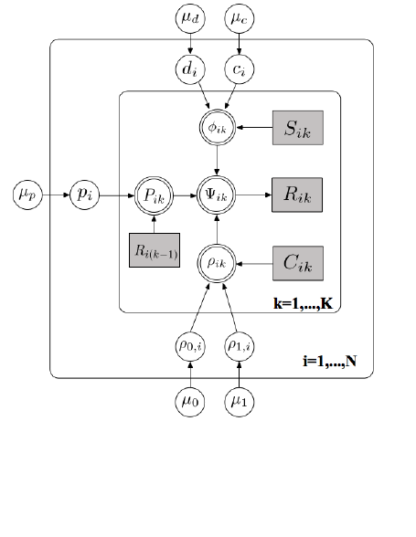

MODELING MINDLESS CHOICE 15

analytic solutions. However, estimates of the posteriors can be obtained using Markov

Chain Monte Carlo (MCMC) methods (Gelman, Carlin, Stern, & Rubin, 2014). MCMC

methods are very ﬂexible, and so very useful, especially because, mixture models can be

very diﬃcult to estimate. MCMC methods allow me to easily add more parameters and

modify the model as needed.

Suggested Models

The model for Study 1

Figure 1 . Bayesian hierarchical model of a mixture of stimulus-based and

stimulus-independent response processes for a simple two-choice task.

The model assumes that there are two processes that generate the behavioral

response. One is the stimulus-based response process and the other is the

stimulus-independent response process described above. These two processes represent

the cases when participants focus on the stimulus and when they fail to pay attention

to the stimulus. The stimulus-based response process is modeled using SDT and the

MODELING MINDLESS CHOICE 16

stimulus-independent process is modeled with the simple two-state Markov Chain.

These two models will be integrated into a single Bayesian hierarchical framework.

This model has three levels that compose the hierarchy: the trial level k, the

subject level i, and the group-level hyperparameters. In Figure 1, to distinguish

between levels, there are two plates that separate the parameters. The innermost plate

represents the trial level (k = 1, ..., K). Stimulus (S

ik

) and condition (C

ik

) are

independent variables selected by the computer program that runs the experiment.

Generation of the stimulus and condition will be explained in Chapter 4. The response

R

ik

follows a Bernoulli distribution with success probability Ψ

ik

. The success

probability Ψ

ik

is a quantity computed from the trial-level quantities φ

ik

, P

ik

and ρ

ik

.

The parameters between the inner plate and outer plate are the individual-level

parameters d

i

, c

i

, p

i

, ρ

0,i

and ρ

1,i

. Note that ρ

ik

is determined by condition C

ik

and

that, depending on condition, ρ

ik

takes on either value ρ

0,i

or ρ

1,i

. The parameters

outside of the outer plate are the group-level hyperparameters µ

d

, µ

c

, µ

p

, µ

0

and µ

1

. We

denote a "signal" decision as 1 and a "noise" decision as 0. The stimulus S

ik

is either a

signal (1) or noise (0) and the condition C

ik

will be explained in the Methods section of

Chapter 4. The probability of a signal response Ψ

ik

is a mixture of the stimulus-based

and stimulus-independent processes, so that

Ψ

ik

= ρ

ik

φ

ik

+ (1 − ρ

ik

)P

ik

. (4)

The stimulus-based response probability φ

ik

arises from signal detection theory, and so

φ

ik

= 1 − Φ(c

i

− S

ik

d

i

). (5)

The value of φ

ik

depends on the criterion (c

i

), discriminability (d

i

) and stimulus type

(S

ik

), and does not depend on the previous decision. Due to the identiﬁability issue, we

decided to constrain c

i

=

d

i

2

. This also applies to Study 3. However, the probability of a

stimulus-independent response,

P

ik

= 1 − p

i

+ R

i(k−1)

(2p

i

− 1), (6)

depends on the previous response. The quantity P

ik

is probability of making a "signal"

decision whereas p

i

is the probability of repeating the previous response. We will

[figure not shown]

MODELING MINDLESS CHOICE 17

parameterize the mixture probability as

ρ

ik

=

1

(1 + exp(ρ

0,i

+ C

ik

ρ

1,i

))

. (7)

As we will explain in the next chapter, the experimental condition will be designed to

diﬀerently motivate participants to pay attention. As we motivate participants more or

less with diﬀerent C

ik

, we expect to see ρ

ik

increase or decrease.

For computational convenience we choose normal priors for the individual-level

parameter

d

i

∼ N(µ

d

, 1). (8)

For the stimulus-independent Markov process, we choose logit-normal priors so that

p

i

∼ logitN(µ

p

, 1), ρ

0,i

∼ N(µ

0

, 1), ρ

1,i

∼ N(µ

1

, 1),

ρ

0,i

=

1

(1 + exp(ρ

0,i

))

and ρ

1,i

=

1

(1 + exp(ρ

0,i

+ ρ

1,i

))

(9)

Finally, for all the hyperparameters,

µ

1

, µ

0

, µ

p

, and µ

s

∼ N(0, 1). (10)

From decades of previous work with the SDT model, the value of the

hyperparameter µ

d

is expected to be anywhere from slightly below zero to a maximum

around 3 or 4. The N(0, 1) prior provides values that are consistent with this prior

knowledge. The parameters µ

p

, µ

0

and µ

1

will be transformed by the logit function, so

the N(0, 1) prior gives more probability weight to values close to 0.5.

Theoretically, there is no reason to use normal priors: any distribution that has

support consistent with our prior knowledge could be used. However, the normal

distribution is computationally convenient and promotes good convergence of chains

produced using Markov chain Monte Carlo (MCMC) techniques.

We will use the estimates of the posterior distributions of these hyperparameters

to measure the eﬀects of experimental conditions across diﬀerent participants.

Parameters of interest are the tendency to repeat the previous response µ

p

, the mean

discriminability µ

d

, and the probability of using the stimulus-based response process ρ,

which is a function of µ

1

and µ

0

. Each hyperparameter controls the behavior of the

individual-level parameters p

i

, d

i

, c

i

, ρ

0,i

and ρ

1,i

.

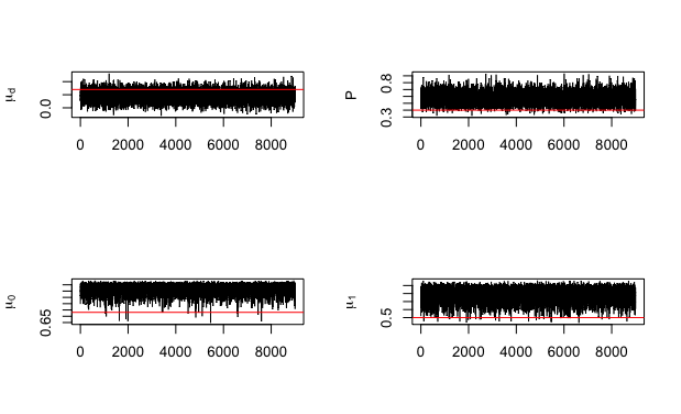

MODELING MINDLESS CHOICE 18

Figure 2 . The trace plots for of 9000 samples (3000 iterations with 3 chains each) from

posterior distribution of hyper-parameters. The red are parameters used to generate the

simulation data.

Parameter Recovery. Parameter recovery is conducted similar manner with

Study 1. Same parameters are used to generated simulation data (µ

0

= 0.7311,

µ

1

= 0.5, d = 0.7, and p = 0.4). Similar to Study 1, the parameter P , mu

0

and mu

1

does not accurately recovered the parameters. Still there is a pattern that µ

0

is higher

than µ

1

which indicates the higher probability of using stimulus based response process

in high motivation condition. (Figure 2)

The model for Study 2

The task in Study 2 is a three-choice task. Therefore, stimulus-based response

process was modeled diﬀerently from Study 1. The three possible responses (R

ik

= 1, 2

and 3) are distributed as

R

ik

∼ Multinomial(Ψ

ik1

, Ψ

ik2

, Ψ

ik3

), (11)

where the three parameters Ψ

ikr

for the multinomial probabilities are mixtures of the

stimulus-based response process φ

ikr

and the stimulus-independent response process

P

ikr

. Regardless of the modiﬁcation in the model both in the stimulus-based and

stimulus-independent components, the mixture model works in the same way as that of

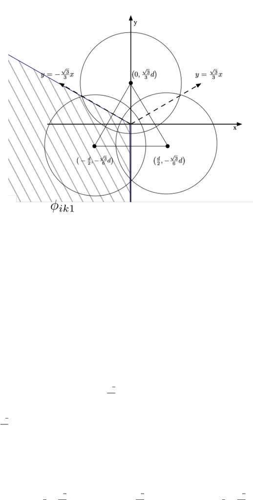

MODELING MINDLESS CHOICE 19

Figure 3 . The circles represent bivariate normal distributions of the perceived stimuli.

The probability φ

ikr

is the volume under the bivariate normal distribution up to the

appropriate linear criteria. For example, the shaded volume is φ

ik1

.

Study 1. The response probabilities φ

ikr

for the stimulus-based response process are

given by the volume under a bivariate normal density up to the perceived boundary

lines (criteria) between three diﬀerent perceived stimulus representations (Figure 3).

For the stimulus S

ik

= 1,2 or 3, P (R

ik

= 1, s) can be written as φ

ik1,s

, calculated as

φ

ik1,s

=

Z

0

−∞

Z

−

√

3

3

x

−∞

BV N

(c

xs

, c

ys

), I

2

dydx. (12)

where −

√

3

3

x represents one of the boundary lines oriented of 120

◦

and BVN is a

bivariate normal distribution with mean vector (c

xs

, c

ys

). The matrix I

2

is a 2 × 2

identity matrix which represents variances of 1 and covariance of 0. For each S

ik

= s,

the mean vectors are

(c

x1

, c

y1

) = (−

d

2

, −

√

3

6

d), (c

x2

, c

y2

) = (0,

√

3

3

d), and (c

x3

, c

y3

) = (

d

2

, −

√

3

6

d), (13)

MODELING MINDLESS CHOICE 20

where the parameter d represents the distance between the mean vectors of each

perceived stimulus representation. However, there is no closed form solution for

Equation 12. To approximate this integral, I used a a sampling technique. I sampled

pairs of x and y coordinates (a

xs

, a

ys

) such that

(a

xs

, a

ys

) ∼ BV N

(c

xs

, c

ys

), I

2

. (14)

After obtaining N samples, I counted the number of coordinate pairs falling in each

region deﬁned by the linear criteria. The proportions of the number of coordinate pairs

falling in each region is an approximate value of the integral in Equation 12. So, for

example, for the case of P (R

ik

= 1|S

ik

= s), φ

ik1,s

can be approximated as,

φ

ik1,s

p

→

1

N

N

X

j=1

(

a

xsj

<0

)(

a

ysj

<−

√

3

3

a

xsj

), (15)

where is an indicator function. In Figure 3, the shaded area (actually volume) is

equivalent to the probability of the randomly sampled coordinates falling inside the

boundary lines. As N increases, the calculation becomes more accurate, but also

increases computational load. Calculating this function value for every iteration in

MCMC procedure is too slow to implement. There is an approximation of polynomial

function with N=1000000 and d = 0 to d = 3 by 0.01 for φ. The approximate function

which is used in the analysis is

φ

ik1,s

≈ 0.33333 + 0.39455(d/2) + 0.11330(d/2)

2

− 0.11426(d/2)

3

+ 0.01773(d/2)

4

. (16)

Computing of φ

ik2,s

and φ

ik3,s

can be done in a similar manner to Equation 15. If the

value of d is high, then there is high discriminability between the diﬀerent stimuli. The

stimuli S

ik

1,2 or 3 are randomly selected with equal probability on each trial.

The stimulus-independent process is modeled similarly to Study 1. This model

has two possible outcomes, repeating the previous decision or not. Assume that the

transition probability P

ik

is given by

P

ik

|(R

ik

= R

i(k−1)

) = p

i

and P

ik

|(R

ik

6= R

i(k−1)

) =

1−p

i

2

, (17)

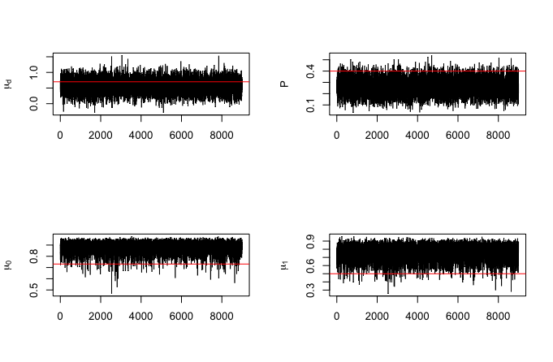

MODELING MINDLESS CHOICE 21

Figure 4 . The trace plots for of 9000 samples (3000 iterations with 3 chains each) from

posterior distribution of hyper-parameters. The red are parameters used to generate the

simulation data.

so that the two decisions that are diﬀerent from the previous decision have the same

probability. The three parameters for the multinomial probability parameters, Ψ

ikr

, are

then mixtures of the stimulus-based response probability and the stimulus-independent

response probability. They can be written as

Ψ

ikr

= ρ

ik

φ

ikr

+ (1 − ρ

ik

)P

ik

(18)

which is very similar structure with that of Study 1.

Parameter Recovery. Parameter recovery is conducted similar manner with

Study 1. Same parameters are used to generated simulation data (µ

0

= 0.7311,

µ

1

= 0.5, d = 0.7, and p = 0.4). The parameter that we want to isolate d

0

is successfully

recovered. However, the parameter P , mu

0

and mu

1

does not accurately recovered the

parameters. Still there is a pattern that µ

0

is higher than µ

1

which indicates the higher

probability of using stimulus based response process in high motivation condition.

To test the identiﬁability of the model, parameter recovery has beend conducted.

The data to ﬁt the model is generated with ﬁxed parameters, µ

0

= 0.7311, µ

1

= 0.5,

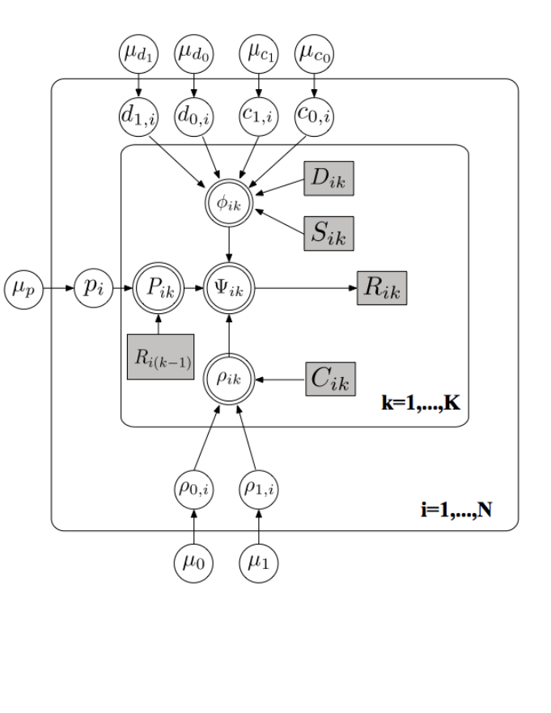

MODELING MINDLESS CHOICE 22

Figure 5 . Bayesian hierarchical model for Study 3. The variable D

ik

indicates task

diﬃculty, where D

ik

= 1 is diﬃcult and D

ik

= 0 is easy.

d = 0.7, and p = 0.4. Figure 4 is posterior using same data generating function. The

most important parameter in this model mu

d

seems to be recovered correctly. However,

estimation in mu

0

and mu

1

has some bias. Still there is pattern of high and low µ

which indicates the probability of using stimulus based response process.

The model for Study 3

In Study 3, we added a component to the stimulus-based response process to

account for level of diﬃculty. Because there are two levels of diﬃculties in Study 3, we

MODELING MINDLESS CHOICE 23

added two new parameters representing discriminability in the second diﬃculty

condition (see Figure 5). The modiﬁed parameters from Study 1 are

d

1,i

∼ N(µ

d

1

, 1) and d

0,i

∼ N(µ

d

0

, 1) (19)

of the model are identical to that of Study 1. We expect the model to discriminate

diﬀerent diﬃculty levels by producing diﬀerent mean discriminabilities µ

d

0

and µ

d

1

.

Simultaneously, regardless of task diﬃculty, we should see the same eﬀects of motivation

on the mixture probability ρ. As in Study 1, we expect to see high ρ in the high

motivation condition, suggesting that people tend to pay more attention to this

condition than in the low motivation condition, regardless of any change in the task

diﬃculty over trials. As the model is very similar to Study 1, there is no parameter

recovery process for Study 3.

Experiments and results

To test the models that we introduced in Chapter 3, we designed three

experiments to ﬁt the models to data. We told participants that they would make

numerosity or categorization judgments under two conditions that would be signaled by

displays of diﬀerent colors. Green "experimental" trials would be used to measure their

performance and red "recalibration" trials would be used to adjust the computer. We

asked the participants to do the task in the same manner in both conditions. We

expected participants to pay more attention to the experimental condition than in the

recalibration condition. This, in turn, should result in a higher probability of using the

stimulus-based response process in the experimental condition.

Study 1

Participants. Thirty-seven participants were recruited from the Ohio State

University Research Experience in Psychology participant pool and received partial

course credit for their involvement. Data from one participant who left the experiment

in the middle of the session was eliminated, so data from 36 participants were used in

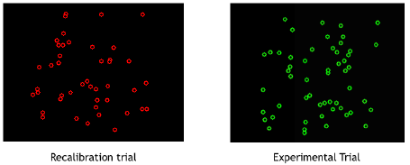

MODELING MINDLESS CHOICE 24

Figure 6 . Stimuli used in the numerosity judgment task. The green and red stimulus

conditions inform participants whether the current trial is a recalibration trial (red) or

an experimental trial (green).

the analysis. All participants were naive to the purposes of the experiment and all

reported normal or corrected-to-normal vision.

Materials. The experiment was run on a PC-style microcomputer running

Ubuntu 14.04. Stimuli, stimulus presentation, timing and response collection were

controlled by scripts written using the OpenSesame application (Mathot, Schreij, &

Theeuwes, 2012). Stimuli were arrays of opaque circles of radius 4 pixels presented

within a square measuring 1280×1024 pixels on each side. The number of circles

presented on each trial was determined by selecting a random number from a normal

distribution rounded to the nearest integer. The location of each circle was determined

by selecting from continuous bivariate uniform distributions deﬁned over the 1280 by

1024 pixels in each square resulting in a display of dot patterns similar to those shown

in Figure 6. Participants responded to each stimulus by pressing "z" or "/" on a

computer keyboard.

Design. The experiment was a 2×2 (Condition by Stimulus) repeated measures

factorial design. The two conditions (C

ik

), high and low motivation corresponding to

the "experimental" and "recalibration" trials, respectively, were blocked over sets of 24

trials. The condition alternated between blocks, with the ﬁrst block consisting of low

motivation trials (C

ik

= 1) followed by a second block of high motivation trials

(C

ik

The stimulus types (S

ik

) were the noise and signal stimuli of SDT. Letting S

ik

= 1

MODELING MINDLESS CHOICE 25

represent signals and S

ik

= 0 represent noise, the numbers of dots were generated from

normal distributions with means equal to 47.5 and 52.5 and standard deviation equal to

5. The stimulus types were decided on each trial by randomly selecting a value for S

ik

with probability 0.5. On average, there were 12 signal and noise trials in each block,

and 528 signal and noise trials for each participant.

Procedure. Participants ﬁrst gave their informed consent. Then they read the

experiment instructions on the monitor while the most important parts of the

instructions were read aloud by the experimenter. The participants were instructed to

determine if the number of circles displayed on each trial was more than 50 or less than

50, and to press "/" on the computer keyboard if the number was greater than 50 and

"z" otherwise. The participants were informed that some displays would be red and

some would be green. They were told that red trials would be used to recalibrate the

computer, whereas green trials would be used to measure their performance, but that

they should perform the task the same way in both conditions.

Each trial began with the presentation of the dot display, which was terminated

by a response. If the response was incorrect, an ‘X’ was presented in the center of the

screen for 100ms, followed by a blank (black) screen for 200ms. If the response was

correct, a blank screen was presented for 300ms. The trial series began with 40 practice

trials. During the practice trials, the experimenter stayed with the participants to

answer questions as needed. After the practice trials, the experimenter gave ﬁnal

instructions and the participant was left alone to perform the remaining 1056 trials.

Calculation of d

0

. From each participant, we obtained measures of stimulus

(S

ik

), condition (C

ik

) and response (R

ik

) over the 1056 trials of the experiment. We

performed no data preprocessing. We ﬁrst examined the eﬀect of the motivation

manipulation by computing the discriminability statistic d

0

for each participant and

motivation condition. Discriminability is estimated as

d

0

= Φ

−1

(hit rate) − Φ

−1

(false alarm rate), (20)

where Φ

−1

is the inverse of the normal cumulative distribution function. The hit rate is

the probability of making a correct decision when a signal was presented. The false

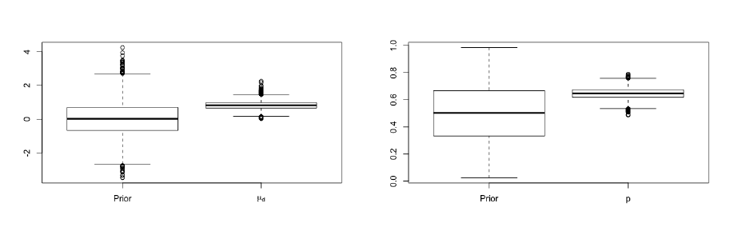

MODELING MINDLESS CHOICE 26

Figure 7 . Prior and posterior distributions of model parameters. The left panel shows

the prior and posterior distributions mean discriminability parameter µ

d

. The right

panel is the prior and posterior distributions of the probability of repeating the previous

response.

alarm rate is the probability of making an incorrect decision when a noise was

presented. Discriminability was higher in the high-motivation condition (mean

d

0

= 0.224, s.e. = 0.031) than in the low motivation condition (mean d

0

= 0.172,

s.e. = 0.027), a diﬀerence that was not signiﬁcant at α equal to 0.05, [t(35) = 1.5055,

p=0.1412]. The diﬀerence is, however, in the expected direction.

Hierarchical Bayesian Analysis. The model described in Suggested Models

section were implemented in Stan (Gelman, Lee, & Guo, 2015). Stan is a probabilistic

programming language that uses No U-Turn Sampling (NUTS) algorithm (Hoﬀman &

Gelman, 2014). After a burn-in period of 300 samples, we obtained 3 chains of 3000

samples, total of 9000 samples from the posteriors of each parameter. Convergence was

conﬁrmed by the Gelman-Rubin convergence statistics

ˆ

R (Gelman & Rubin, 1992):

every set of parameter chains had

ˆ

R ≈ 1.

The estimated posteriors of the hyperparameters are shown in Figure 7. The left

panel shows the estimated posteriors of the mean discriminability parameter together

with their prior. The right panel shows the mean probability of repeating the previous

decision together with its prior distribution. The mean discriminability parameter µ

d

has a posterior mean of 0.8175 and posterior 95% highest density interval (HDI) of

[0.357 ,1.339]. This is much higher than calculation of d

0

without mixture model of

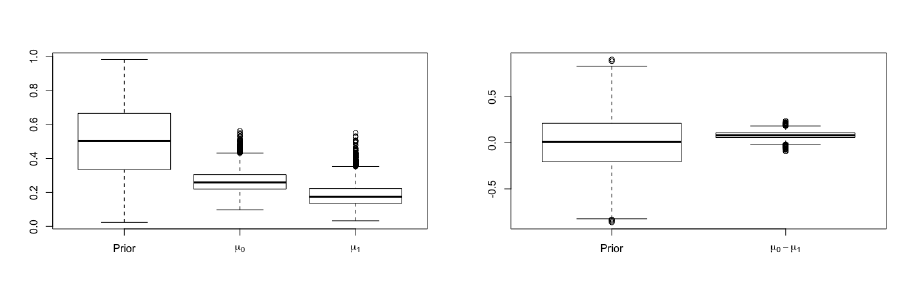

MODELING MINDLESS CHOICE 27

Figure 8 . The left panel shows the posterior distributions for probability of using

stimulus-independent response in high motivation condition (µ

0

) and low motivation

condition (µ

1

) with its prior distribution. The right panel shows the posterior

distribution of µ

0

− µ

1

in Study 1.

stimulus based and stimulus independent response process. The probability of repeating

the previous response, 1/(1 + exp(µ

p

)) has an estimated a posterior mean of 0.645 and

95% HDI of [0.563, 0.722].

The posterior mean of µ

0

in the high motivation condition is 0.2656 and the 95%

HDI is [0.150, 0.395]. The posterior mean of µ

1

in the low motivation condition is 0.184

and the 95% HDI is [0.07, 0.318]. More importantly, the posterior distribution of the

diﬀerence between values of µ for the two conditions has a mean of 0.0812 and the 95%

HDI of [0.001, 0.156].

The beauty of Bayesian hierarchical modeling is that it is possible to analyze

eﬀects at both the group level and the individual level. Figure 9 shows the estimated

posterior distributions of ρ

0,i

− ρ

1,i

, which reﬂects the eﬀect of motivation for each

For demonstration purposes, the analysis of individual participant was conducted

0,30

− ρ

1,30

had a mean of 0.5472 with 95% HDI of [0.3934, 0.6901] and

d

30

had a mean of 0.5021 with HDI of [.1900, 0.8347]. The participant tend to focus

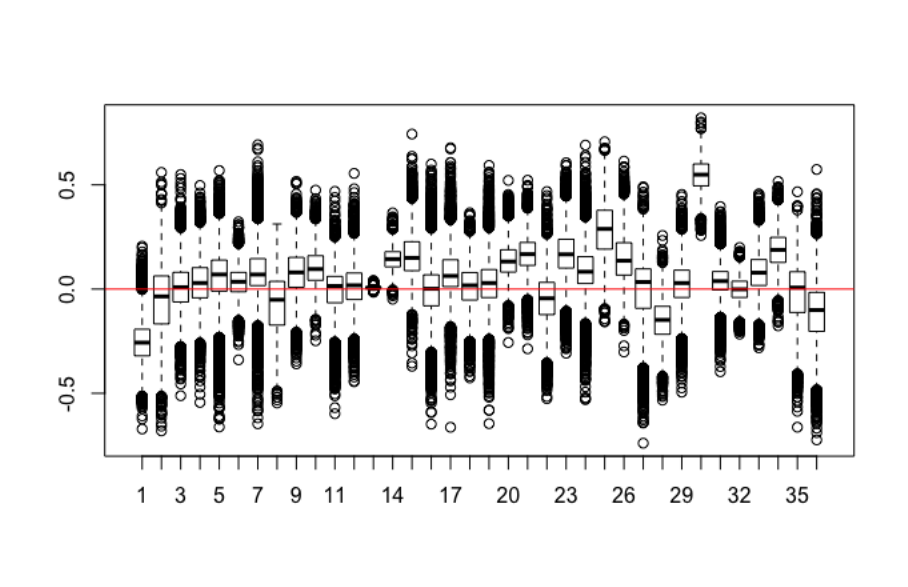

MODELING MINDLESS CHOICE 28

Figure 9 . Posterior distributions of ρ

0,i

− ρ

1,i

for each of 36 participants in Sutdy1.

more on motivation condition with okay discriminability.

Study 2

In this experiment, we generated categorization data to test a version of the model

expanded to account for performance in a three-choice task.

Design. Study 2 is a three-choice expansion of Study 1. The new task asks

participants to identify stimuli that arise from one of three diﬀerent regions in stimulus

array (Figure 11). A bird appears from one of the regions, Z, C or X. These regions are

not identiﬁed for the participant except during the instruction phase of the experiment.

The stimuli are constructed in such a way that the geographic centers of each region are

equidistant and the angles of separation as deﬁned by optimal response criteria are also

equal. These equivalences allow me to retain the same parameterization of the

stimulus-independent response process as in Study 1.

On each trial, the stimulus is selected with equal probability (1/3) from one of the

three regions. Using the central point of each region as a mean, the stimulus’s X and Y

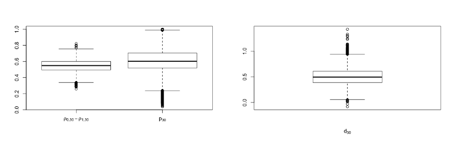

MODELING MINDLESS CHOICE 29

coordinates are generated from bivariate normal distributions with variance of 1. The

mean vectors of each distribution are

(x

1

, y

1

) = (−2.037 cos(π/4), −2.037 cos(π/4)), (21)

(x

2

, y

2

) = (2.037 cos(15π/180), 2.037 sin(15π/180)), and (22)

(x

3

, y

3

) = (−2.037 cos(75π/180), −2.037 sin(75π/180)). (23)

Because a stimulus can be presented closer to the center of another region than to the

center of its own, there is a possibility of error. The trigonometric terms in Equation

21∼23 works to keep angles of 120

◦

between the mean vectors of each pair of stimulus.

We selected the radius of 2.037 is selected to maintain approximately the same error

rate as in Study 1 (about 30 percent). We conducted this experiment with two diﬀerent

motivation conditions (bird colors): red birds indicated recalibration (low motivation)

trials and green birds indicated experimental (high motivation) trials. Including the

motivation condition, the experiment was conducted in the same way as that of Study 1.

Method. Forty-two participants were recruited from participant pool at the

Ohio State University. Four of the participants were eliminated because they did not

ﬁnish the task. So, data from 38 participants were used for analysis. Other details were

same as Study 1.

Calculation of d

0

The d

0

is calculated by using correct response rate using polynomial. It is the

discriminability without consideration of sequential dependency Mean d

0

is 0.9320

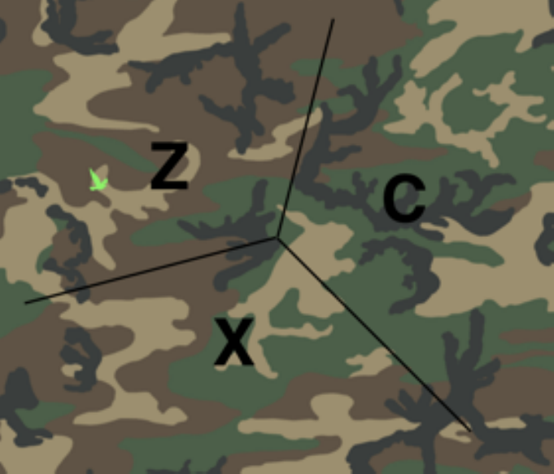

MODELING MINDLESS CHOICE 30

Figure 11 . The task instruction for Study 2. This ﬁgure is presented to participants to

understand the task. In this case, ’Z’ will be the best decision. Area name Z, C, X and

boundary lines are presented only for the instruction.

(s.e.=0.0532). The maximum of discriminability among subject was 1.3384 and

minimum was 0.1829

Hierarchical Bayesian Analysis. The posterior mean of discriminabilty is

µ

d

=1.3695 and posterior 95% HDI is [1.027, 1.843]. The probability of repeating the

previous response, 1/(1 + exp(µ

p

))’s posterior means is 0.526 and HDI of [0.426, 0.630].

There is no condition eﬀect found that the ρ for high and low condition eﬀect were

similar [µ

0

=0.723 µ

1

=0.69]. It seems that condition eﬀect did work in the study 3. The

individual eﬀect of participants 3 shows better performance on the task.

The Participant 14 is picked for individual analysis. The posterior mean of d

14

is

1.0241 with HDI of [0.3995, 1.9701]. The probability of repeating previous decision, p

1

4

is 0.5867 with HDI of [0.4531, 0.8235]. The diﬀerence of rho

01

4 and rho

11

4 has posterior

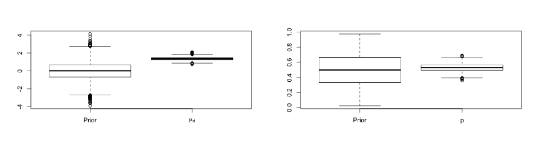

MODELING MINDLESS CHOICE 31

Figure 12 . Prior and posterior distributions of model parameters µ

d

(left panel) and p

(right panel).

Study 3

The purpose of Study 3 was to verify that the model behaves appropriately under

manipulations of task diﬃculty.

Design. We modiﬁed the design of Study 1 using two levels of diﬃculty (easy

and hard). Blocks of 24 low and high motivation trials were nested within diﬃculty.

Easy and hard super-blocks of 48 trials each repeated in turn 11 times, giving 1056

trials in total. The distance between the mean of signal and noise distribution of the

easy blocks was increased to 2 standard deviations. The diﬃcult blocks have the same

distance (1 standard deviation) as Study 1. In the easy blocks, the number of dots on

the screen for the noise stimulus was generated from a N (45, 5) distribution, and for the

signal stimulus was generated from a N(55, 5) distribution.

Method. Fifty participants were recruited the same way as in Study 1. Data

from one participant who did not ﬁnish the task was eliminated, so data from 49

participants were used for analysis. Participants were not informed of the diﬃculty

manipulation.

Calculation of d

0

. From each participant, we obtained measures of stimulus

(S

ik

), condition (C

ik

), response (R

ik

) and diﬃculty (D

ik

) over the 1056 trials of the

experiment. We performed no data preprocessing. First, we conducted a two-way

repeated-measures analysis of variance to examine the two main eﬀects (motivation and

diﬃculty) and their interaction on d

0

. The analysis showed no signiﬁcant interaction

between motivation and diﬃculty (F (1, 192) = 0.0026, p = 0.9592) and no main eﬀect

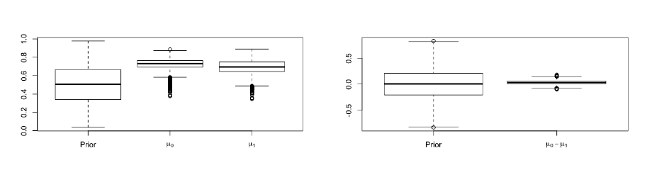

MODELING MINDLESS CHOICE 32

Figure 13 . The left panel shows the posterior distributions for probability of using

stimulus-independent response in high motivation condition (µ

0

) and low motivation

condition (µ

1

) with its prior distribution. The right panel shows the posterior

distribution of µ

0

− µ

1

in Study 2.

of motivation (F (1, 192) = 1.8950, p = 0.1702). There was, however, a signiﬁcant eﬀect

of diﬃculty (F (1, 192) = 48.1937, p < 0.001). Table 4.2, shows the mean d

0

for the

diﬃculty and motivation conditions. There was a tendency for participants to perform

better in the high motivation condition, but the eﬀect did not reach signiﬁcance.

Hierarchical Bayesian Analysis. In Figure 16, the left panel shows the

estimated posteriors of the mean discriminability for each diﬃculty level together with

their prior distribution. The right panel shows the mean probability of repeating the

previous decision together with its prior distribution. The mean discriminability

parameter for easy task µ

d

1

d

0

has a

The probability of repeating the previous response p has an estimated posterior

mean of 0.651 and 95% HDI of [0.586, 0.721].

The parameter of greatest interest is the mixture probability µ which should have

been aﬀected by the motivation manipulation. For the high motivation condition, µ

0

has a posterior mean of 0.333 and a 95% HDI is [0.242, 0.436]. For the low motivation

condition, µ

1

has a posterior mean of 0.254 and 95% HDI of [0.156, 0.360]. More

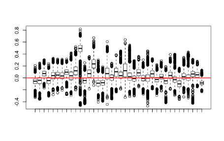

MODELING MINDLESS CHOICE 33

Figure 14 . All individual’s diﬀerence in ρ

0

and ρ

1

in Study 2.

Figure 18 shows the estimated posterior distributions of ρ

0,i

− ρ

1,i

, for each

participant i. For demonstration, in the same way to Study 1, we picked two individuals

ρ between high and low motivation conditions has a mean of 0.1625, and 95% HDI of

[-0.0094, 0.3416]. This indicated that s/he had no big diﬀerence in two diﬀerent

conditions. Participant 9 showed pretty good discrimination in both conditions.

(Posterior mean of d

0,9

=0.8025 with HDI

[0.4611, 1.6789]) Participant 9 tended to repeat his/her responses (posterior mean p

9

Discussion

Over three studies, we built mixture models for simple choice composed of two

diﬀerent processes. One process generates, with probability 1 − ρ, responses that are

stimulus-independent and the other generates, with probability ρ, responses that

depend on the stimulus. If it is possible to model the stimulus-independent process

instead of trying to identify and isolate contaminates, we could make better use of data.

A key idea is that response dependency between trials is assumed to come from

the stimulus-independent response. Under this assumption, we developed a model for

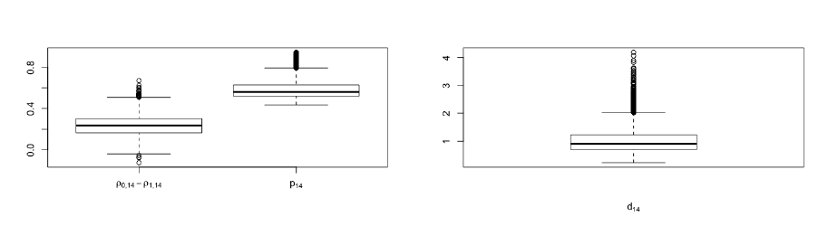

MODELING MINDLESS CHOICE 34

Figure 15 . Posterior distributions of model parameters for Participant 14 in Study 2.

the stimulus-independent process using a Markov chain that can insert dependency

between trials. The stimulus-based response process is based on signal detection theory

(SDT) which is commonly used to model two-choice tasks.

We designed three experiments to test the utility of this modeling strategy.

Experiments for Study 1 and Study 3 were two-choice numerosity tasks. One diﬀerence

experimental design between Study 1 and Study 3 is the task diﬃculty. Study 1’s task

had only one diﬃculty level, but Study 3 had two diﬀerent task diﬃculties. Study 2

used a 3-choice task. To make a 3-choice task with equal distance between the means of

the stimulus distributions, we developed a location classiﬁcation task. The task was to

classify the origination of stimulus using its presented location.

Study 1 and Study 3 showed that we can discriminate between stimulus-based and

stimulus-independent processes as indicated by a higher value of ρ in high motivation

conditions. Study 3 with two levels of task diﬃculty, showed higher values of the

discriminability parameter d in easy conditions. The results of Study 2 did not show

any diﬀerence in ρ for high and low motivation conditions. Even without condition

eﬀect, the posterior distribution of d and p spanned a plausible range of values.

Although the three studies had diﬀerent experimental designs, the main framework

is a mixture model of stimulus-dependent and stimulus-independent processes. The

probability parameter of the mixture model ρ is interpreted as the probability of using

the stimulus-based response over the stimulus-independent response. In these studies,

we observed a higher probability ρ of using the stimulus-based response process in high

motivation conditions. This result is consistent with the idea of decomposing the

[figure not shown]

MODELING MINDLESS CHOICE 35

Diﬃculty Low High High-Low

d

0

0

0.502 (S.E.=0.030) 0.561 (S.E.=0.037) 0.056 (t(48)=1.6155)

d

0

1

0.213 (S.E.=0.046) 0.268 (S.E.=0.052) 0.06 (t(48)=1.6336)

response process into the stimulus-based and stimulus-independent response processes.

The main point is that, by allowing the model to separate the two processes, we can

estimate more accurately the parameters d and c of the stimulus-based response process.

This modeling strategy can be fruitful in two ways. First, isolating the eﬀect of

the stimulus-independent process can help researchers examine an eﬀect of interest

without performing data preprocessing to remove contaminants. Second, the

phenomena involved in failing to pay attention during an experiment is worth studying

as a topic of research in and of itself.

In Study 2, even though participants tended toward better discriminability in high

motivation conditions according to a frequentist analysis of d

0

, the posterior distribution

of the parameters of the Bayesian model did not show strong evidence for higher

probabilities of using the stimulus-based response process. We assumed there is a single

d, distance between the three means, with ﬁxed criteria reﬂecting no bias. This

assumption may not be valid. The estimates of d derived from pairwise comparisons

between distributions suggested that the distances between the perceived stimuli may

be a lot diﬀerent from each other. Allowing d to vary might improve the model ﬁt as

might allowing variations in criteria.

The biggest issue of the model suggested in the paper might be an identiﬁability

problem. As shown in the model section, it seems that parameter recovery is not

accurate for ρ and p parameters. Still discriminability seems to recovered which is

mostly the parameter of interest. Also, the pattern of diﬀerence between ρ

0

and ρ

1

tends to be consistent. In the purpose of eliminating the contamination of sequential

eﬀect, the model is doing some function. However, interpretation of ρ and p is still in

question, because there is high possibility that the estimate is biased

In all three studies, there was a strong assumption of the role played by

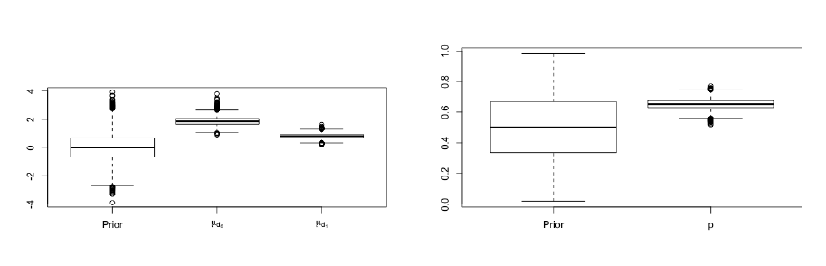

MODELING MINDLESS CHOICE 36

Figure 16 . Prior and posterior distributions of model parameters for Study 3. The left

panel shows the prior and posterior distributions of the signal detection parameters.

The right panel shows the prior and posterior distributions of the probability of

repeating the previous response.

dependency between trials. The reason for this assumption comes from the fact that, if

the stimulus is generated as an iid sequence then the sequence of responses should be at

least approximately iid if the participant responds only on the basis of the stimulus.

However, there might be dependencies between trials that are relevant to the task. For

example, if a participant was not good at discriminating between stimuli in the early

trials, then eventually, from the successes and failures of previous trials, the participant

will learn how to do better in the task. Such learning cannot be considered as either

stimulus-independent responding or mind wandering. The current model ignores such

long-term trends over the sequence of responses.

Future Work

Future research will need to consider the cause of failure of parameter recovery. If

we can reproduce the pattern of overestimation of d then, we will be able to determine

hyperparameters, except for the ρ

0

and ρ

1

which seems okay to have the correlations, it

We also plan to collect neural evidence for the behavioral model in this study.

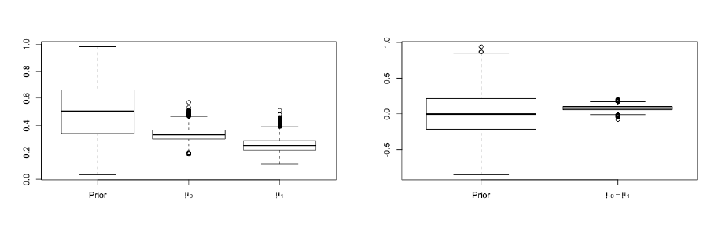

MODELING MINDLESS CHOICE 37

Figure 17 . The left panel shows the posterior distributions for the mixture probability

µ for high and low motivation (experiment and recalibration) conditions with its prior

distribution. The right panel shows the posterior distribution of the µ under the

diﬀerence in high and low motivation conditions.

From previous studies, we know that mind wandering or task-unrelated thoughts are

related to a neural system called the Default Mode Network (DMN; Raichle, 2007). The

goal is to relate the model parameters to activation of the DMN, and by so doing,

further test the validity of the model. We have already collected pilot data from three

participants. In the pilot study, We looked for a relationship between changes in the

mixture probability parameter ρ

i

between high and low motivation conditions to the

brain areas implicated in the DMN (posterior cingulate cortex, medial prefrontal cortex,

and angular gyrus). Only one participant showed any diﬀerence of ρ

i

in high and low

motivation conditions, and that participant showed signiﬁcantly higher activation of

those brain areas in the low motivation condition relative to the high motivation

condition. This suggests that ρ

i

can be related to activation of the DMN. There are

three things We need to do to develop this study. First, we need to test more

participants. Second, we will need to examine more carefully the connections between

the areas which compose the DMN. Third, the current design of the experiment has no

lags between the transition of conditions. Because the hemodynamic response is slow

compared to the speed of the task, there might be an overlap of the hemodynamic

responses between diﬀerent conditions. We need to develop a new experimental design

to avoid this problem.

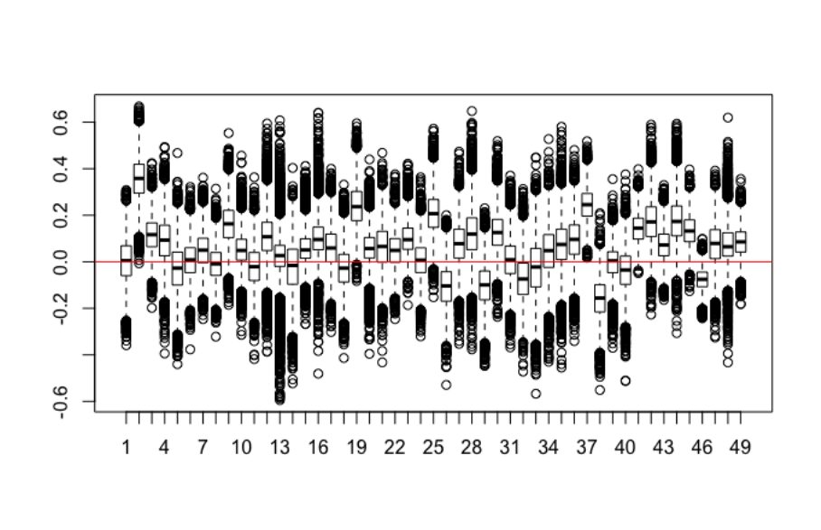

MODELING MINDLESS CHOICE 38

Figure 18 . Posterior distributions of ρ

0,i

− ρ

1,i

for each of 49 participants.

Conclusion

Modeling task-unrelated processes is a useful way to avoid wasting data by

preprocessing. Using a mixture model, we decomposed the response process into

stimulus-based and stimulus-independent processes. The results of Study 1 and Study 3

show that it is possible to detect changes in the probability of using the two diﬀerent

processes under diﬀerent motivation conditions in a two-choice task. However, we still

have problem with identiﬁability problem for some of the parameters in the model. It is

important to modify model to have all parameters identiﬁable.

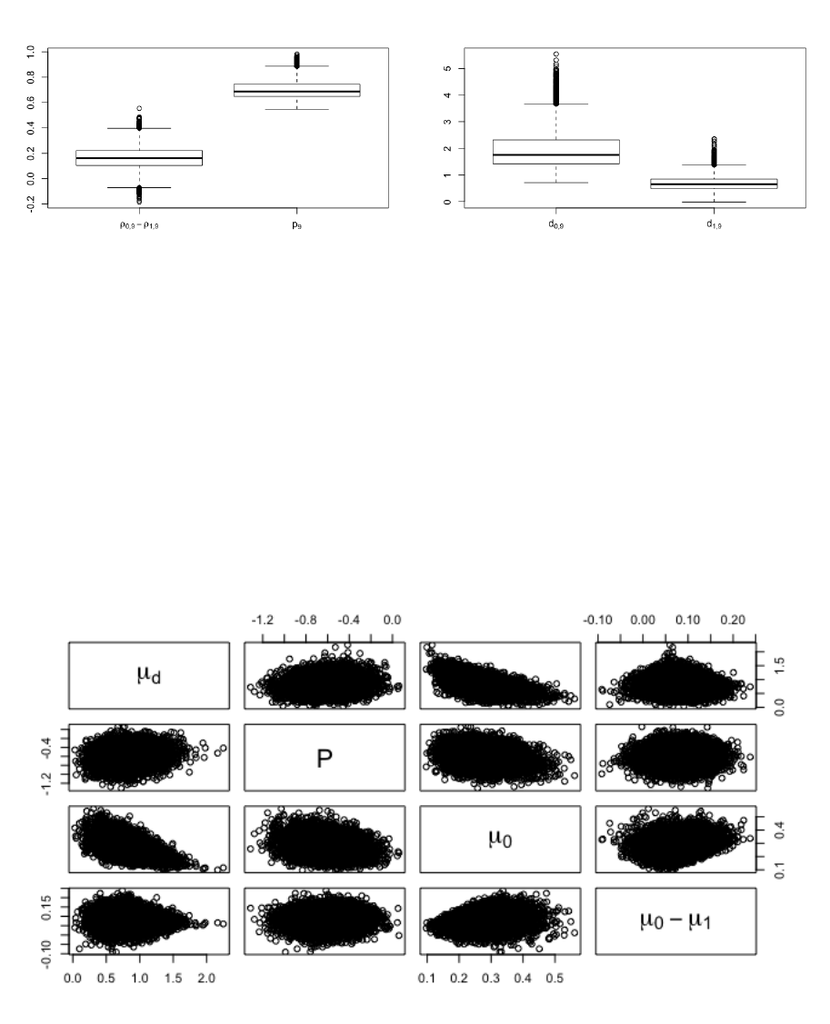

MODELING MINDLESS CHOICE 39

Figure 19 . Prior and posterior distributions of model parameters for Participant 9 in

Study 3.

Figure 20 . Correlation plot for hyper parameters in Study 1

MODELING MINDLESS CHOICE 40

References

Audley, R., & Pike, A. (1965). “ Some alternative stochastic models of choice.”. British

Journal of Mathematical and Statistical Psychology(18), 207-225.

Bakan, P. (1960, March). “Response-Tendencies in Attempts to Generate Random

Binary Series”. The American Journal of Psychology, 73 (1), 127-131.

Barnett, V., & Lewis, T. (1994). Outliers in Statistical Data. John Wiley.

Craigmile, P. F., Peruggia, M., & Van Zandt, T. (2010). “Hierarchical Bayes Models for

Response Time Data.”. Psychometrika, 75 , 613-632.

Gelman, A., Carlin, J. B., Stern, H. S., & Rubin, D. B. (2014). Bayesian data analysis

3. Boca Raton, FL, USA: Chapman Hall/CRC.

Gelman, A., Lee, D., & Guo, J. (2015). Stan: A probabilistic programming language for

bayesian inference and optimization. Journal of Educational and Behavior

Science.

Gelman, A., & Rubin, D. (1992). “ Inference from Iterative Simulation Using Multiple

Sequences.”. Statistical Science(7), 457-511.

Green, D., & Swets, S. (1966). Signal detection theory and psychophysics. J Wiley New

York.

Hastings, C., Mosteller, F., Tukey, J. W., & Winsor, C. P. (1947). “Low moments for

small samples: a comparative study of order statistics”. Annals of Mathematical

Statistics, 18 (3), 413-426.

Hawkins, D. (1980). Identiﬁcation of Outliers. Identiﬁcation of Outliers.

Hoﬀman, M., & Gelman, A. (2014). The no-u-turn sampler: Adaptively setting path

lengths in hamiltonian monte carlo. Journal of Machine Learning Research, 15 ,

1351-1381.

Kim, S., Potter, K., Craigmile, P. F., Peruggia, M., & Van Zandt, T. (2016). “A

Bayesian Race Model for Recognition Memory.”. Journal of the American

Statistical Association.

Logan, G. (1990, November). “Analysis of sequential eﬀects on choice reaction times.”.

Journal of Experimental Psychology,, 82 (2), 250-257.

MODELING MINDLESS CHOICE 41

Mathot, S., Schreij, D., & Theeuwes, J. (2012). “OpenSesame: An open-source,

graphical experiment builder for the social sciences”. Behavior Research Methods,

44 (2), 314-324.

Ratcliﬀ, R. (1993). “Methods for Dealing With Reaction Time Outliers”. Psychological

Bulletin, 114 (3), 510-532.

Remington, R. (1969, January). “Repetition priming and automaticity: Common

underlying mechanisms?”. Cognitive Psychology, 22 (1), 1-35.

Rivest, L. P. (1994). “Statistical Properties of Winsorized Means for Skewed

Distributions”. Biometrika, 81 (2), 373-383.

Taylor, H. M., & Karlin, S. (1998). An Introduction to Stochastic Modeling (Third ed.).

Academic Press.

Townsend, J., & Ashby, G. (1965). “ Some alternative stochastic models of choice.”.

British Journal of Mathematical and Statistical Psychology(18), 207-225.

Ulrich, R., & Miller, J. (1994). “Eﬀects of truncation on reaction time analysis.”.

Psychological Bulletin, 123 (1), 34-80.

Van Zandt, T. (2002). Analysis of response time distributions. In Stevens’ handbook of

experimental psychology. John Wiley.

Van Zandt, T., Colonius, H., & Proctor, R. (2000). “ A comparison of two responses

models applied to perceptual matching.”. Psychonomic Bulletin and Review(27),

208-256.

Wagenaar, W. A. (1972). “Generaton of Random Sequences by Human Subjects: A

Critical Survey of Literature”. Psychological bulletin, 77 (1), 65-72.

Zimmerman, D. W. (1994). “A note on the inﬂuence of outliers on parametric and

nonparametric tests.”. Journal of General Psychology, 121 (4), 391–401.